# Homework 4

Scott Dolan

9/22/2020

> Stat 401 Homework 4 Due 9/27/2020 The following homework assignments should be done using R (when appropriate). Page 77-78 #1, 3, 6, 7, 9, 12 Page 88-89 #3, 6, 8, 10 Page 96 #1, 4, 5, 10

## Page 77 Problem 1

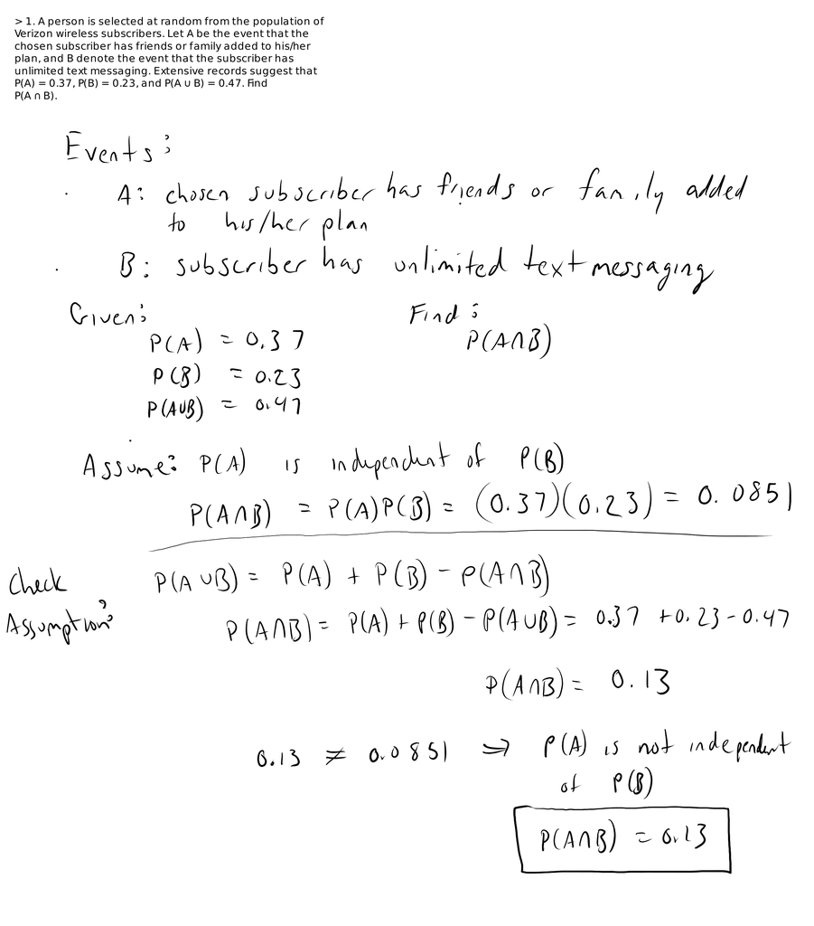

## Page 78 Problem 3

> 3. A new generation of hybrid vehicles achieves high- way gas mileage in the range of 50 to 53 MPG. The gas mileage of three such cars, during a pre-specified 100-mile drive, will be rounded to the nearest integer, resulting in the sample space S = {(x 1 , x 2 , x 3 ) : x i = 50, 51, 52, 53}, i = 1, 2, 3.
> 1. Assume that the outcomes of the sample space S are equally likely, and use R commands similar to those used in Example 2.4-1 to find the probability mass function of the experiment that records the average mileage the three cars achieve.

```r
x=c(50,51,52,53)
Sx <- expand.grid(X1=x, X2=x, X3=x)
attach(Sx)
pmf.s <- table((X1+X2+X3)/3)/dim(Sx)[1]
pmf.s
```

```
##
##               50 50.3333333333333 50.6666666666667               51
##         0.015625         0.046875         0.093750         0.156250
## 51.3333333333333 51.6666666666667               52 52.3333333333333
##         0.187500         0.187500         0.156250         0.093750
## 52.6666666666667               53
##         0.046875         0.015625
```

> 2. Use the PMF obtained in part (a) to compute the probability that the average gas mileage is at least 52 MPG.

```r
cat(paste0('The probability that the average gas milage is at least 52 MPG is: ',pmf.s["52"]))
```

[output not shown]

## Page 78 Problem 6

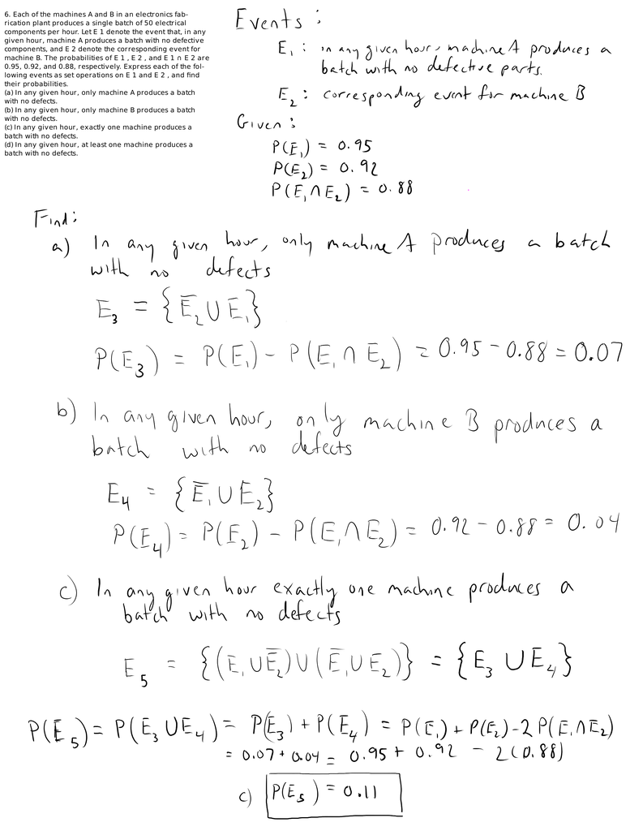

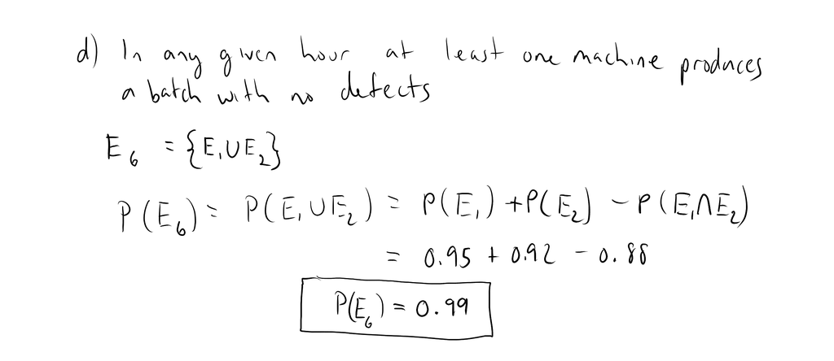

## Page 78 Problem 7

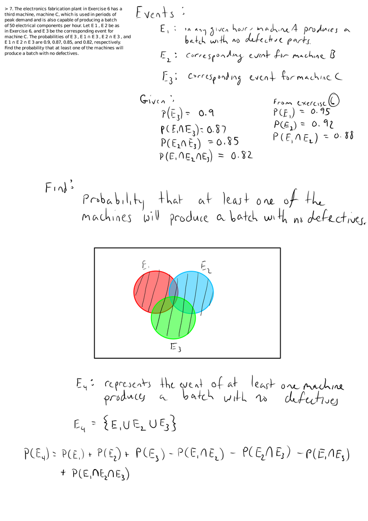

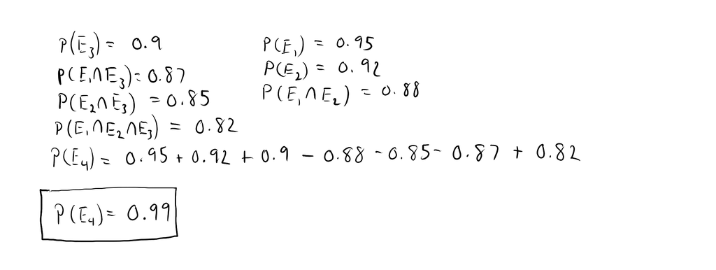

## Pages 78-79 Problem 9

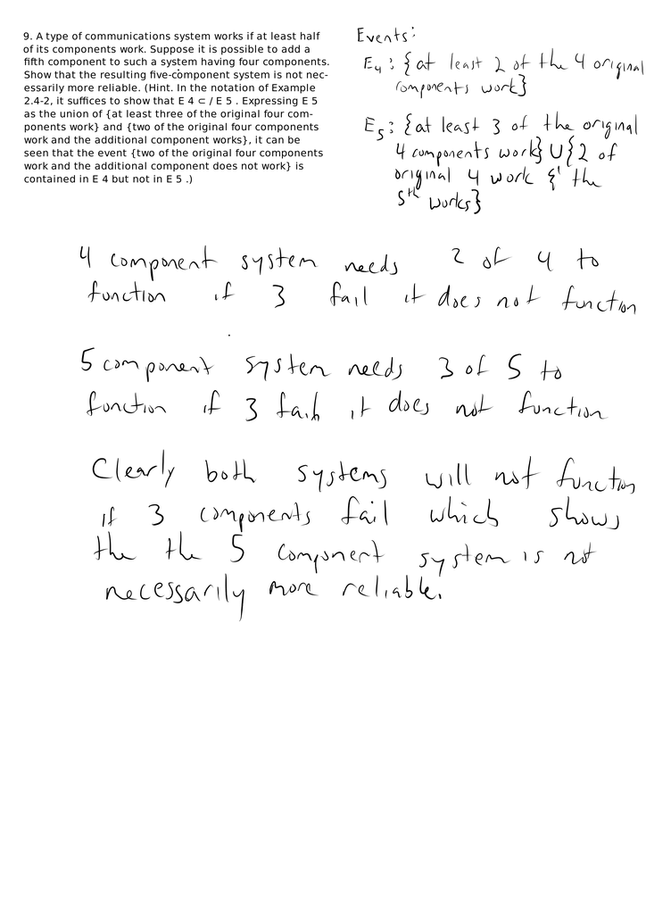

## Page 79 Problem 12

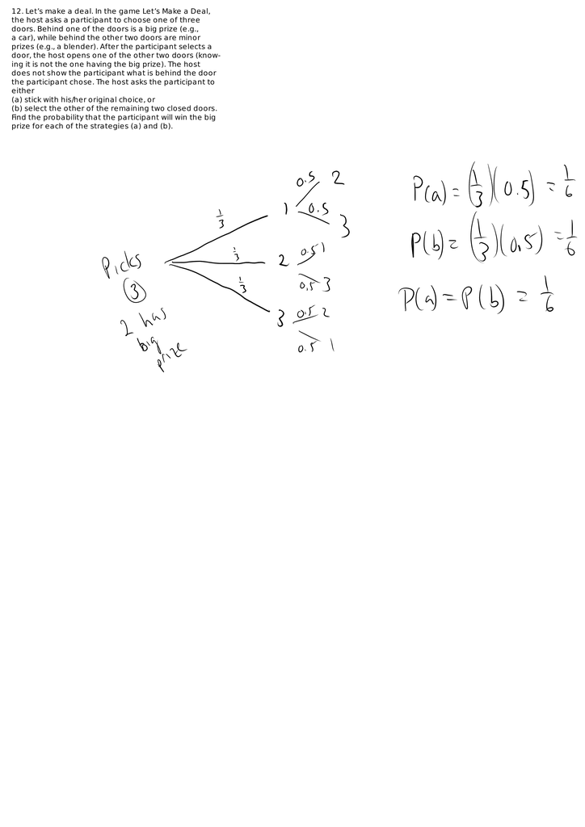

## Page 88 Problem 3

> Let A and B be the events that X = 1 and Y = 1, respectively. (a) Find the probability of A. (b) Find the conditional probability of B given A. (c) Find the probability mass function of the random variable X.